# Generating and Analyzing Brain Networks with Community Structures

Maximiliano Martino, Daniel Fraiman

2026-09-23

## Overview

This vignette shows the full `BrainNetTest` workflow on synthetic populations of brain networks with community (block) structure. We simulate two groups of graphs with different intra- and inter-community connection probabilities, run the global L1-distance ANOVA test, and identify the edges and nodes that drive the observed difference.

```r
library(BrainNetTest)
```

## Generating a single community-structured graph

`generate_community_graph()` samples a symmetric binary adjacency matrix with a block-stochastic structure: edges within a community are drawn with probability `intra_prob`, edges between communities with `inter_prob`.

```r
set.seed(42)
G <- generate_community_graph(
  n_nodes       = 40,
  n_communities = 4,
  intra_prob    = 0.8,
  inter_prob    = 0.2)

dim(G)
```

```
#> [1] 40 40
```

```r
mean(G[upper.tri(G)])
```

```
#> [1] 0.3358974
```

### Visualising the network

A single community-structured adjacency matrix is best inspected directly with `igraph`. The package’s own visualisation helper, `plot_critical_edges()`, is designed to summarise the *result* of an analysis (per-population central graphs plus the identified critical edges) and is illustrated at the end of this vignette.

## Simulating populations of graphs

`generate_category_graphs()` produces a list of graphs that share a common community structure but vary slightly in their edge probabilities across replicates, modelling natural between-subject variability.

```r
control <- generate_category_graphs(
  n_graphs             = 20,
  n_nodes              = 20,
  n_communities        = 2,
  base_intra_prob      = 0.8,
  base_inter_prob      = 0.2,
  intra_prob_variation = 0.05,
  inter_prob_variation = 0.05,
  seed                 = 1)

patient <- generate_category_graphs(
  n_graphs             = 20,
  n_nodes              = 20,
  n_communities        = 2,
  base_intra_prob      = 0.6,
  base_inter_prob      = 0.4,
  intra_prob_variation = 0.05,
  inter_prob_variation = 0.05,
  seed                 = 2)

populations <- list(Control = control, Patient = patient)
lengths(populations)
```

```
#> Control Patient
#>      20      20
```

## Global test statistic

```r
T_obs <- compute_test_statistic(populations, a = 1)
T_obs
```

```
#> [1] -85.03753
```

## Identifying critical edges

`identify_critical_links()` performs the full pipeline: marginal edge p-values, permutation null for `T`, and iterative edge removal. It returns the edges whose removal eliminates the group-level difference.

```r
result <- identify_critical_links(
  populations,
  alpha          = 0.05,
  method         = "fisher",
  n_permutations = 500,
  seed           = 42)

result
```

```
#>
#> Critical edges between populations of brain networks
#>
#> Populations:     2 (Control, Patient), 20 / 20 graphs
#> Candidate edges: 190
#> Global test:     p < 0.002 (500 permutations, alpha = 0.05)
#> Critical edges:  50 of 190 (26.3%), ranked by Fisher's exact test
#>
#> Most significant 6 of them:
#>   node1 node2      p_value
#> 1    14    20 0.0004359198
#> 2    12    16 0.0021996412
#> 3     5    11 0.0033420517
#> 4     1    12 0.0033420517
#> 5    10    12 0.0033420517
#> 6    17    18 0.0033420517
#> ... 44 more; see the critical_edges component
```

### Critical nodes

`get_critical_nodes()` aggregates the critical edges at the node level, reporting the *critical degree* (number of critical edges incident on each node):

```r
get_critical_nodes(result)
```

```
#>    node critical_degree
#> 1    12              10
#> 2    16               8
#> 3    14               7
#> 4    17               7
#> 5    20               7
#> 6     1               6
#> 7     5               6
#> 8    19               6
#> 9     3               5
#> 10    6               5
#> 11    9               5
#> 12    2               4
#> 13    8               4
#> 14   11               4
#> 15   13               4
#> 16   15               4
#> 17    4               3
#> 18   10               2
#> 19   18               2
#> 20    7               1
```

## Visualising the result

`plot_critical_edges()` produces a multi-panel figure that summarises the analysis: one panel per population showing the (weighted) central graph, plus a final panel that highlights the critical edges on the chosen reference central graph. Communities can be passed in to color the vertices consistently across panels.

Because the result is a `critical_links` object, `plot()` dispatches to that function. The populations have to be passed in, since the object stores the *modified* populations, from which the critical edges have been removed.

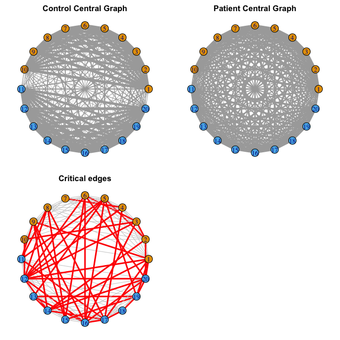

```r
plot(
  result,
  populations,
  communities = rep(seq_len(2), each = 10),
  reference   = "Control")
```

## References

Fraiman, D. and Fraiman, R. (2018) An ANOVA approach for statistical comparisons of brain networks. *Scientific Reports*, 8, 4746. https://doi.org/10.1038/s41598-018-23152-5